# **Telecom Data Analysis Project to Improve Service Quality**

### **Age and Customer Satisfaction Score**

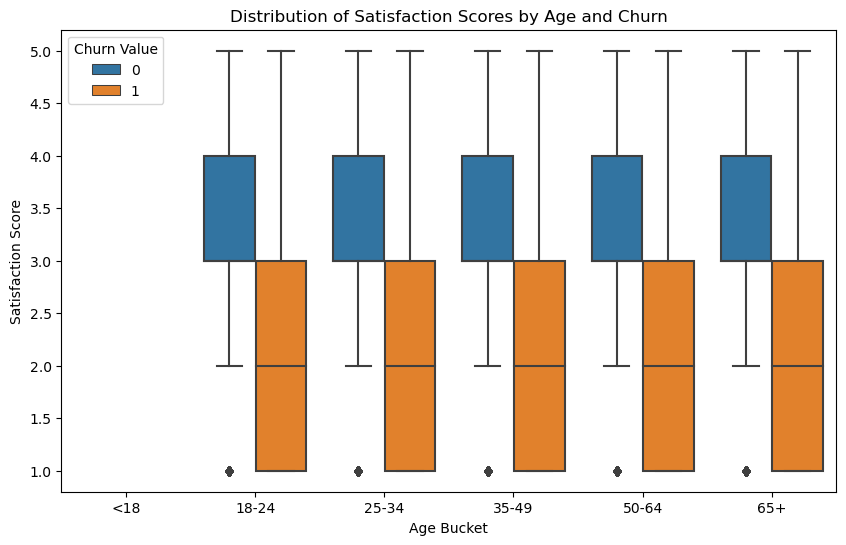

```
Churn Value         0         1
age_bucket
<18               NaN       NaN
18-24        3.187138  1.989203
25-34        3.187204  1.975575
35-49        3.186785  1.996815
50-64        3.181291  2.001151
65+          3.191100  1.990071
```

```python
# boxplot to visualize the distribution of satisfaction scores for each age bucket

plt.figure(figsize=(10,6))
sns.boxplot(data=df, x='age_bucket', y='Satisfaction Score', hue='Churn Value')
plt.title('Distribution of Satisfaction Scores by Age and Churn')
plt.xlabel('Age Bucket')
plt.ylabel('Satisfaction Score')
plt.show()

# Calculate the mean satisfaction score for each age bucket and churn group
age_satisfaction = df.groupby(['age_bucket', 'Churn Value']).agg({'Satisfaction Score': 'mean'}).reset_index()

# Pivot the table to make the churn values into columns
age_satisfaction = age_satisfaction.pivot(index='age_bucket', columns='Churn Value', values='Satisfaction Score')
print(age_satisfaction)
```

**Observation**:

- Overall, the mean satisfaction scores are relatively similar across all age buckets, ranging from 3.18 to 3.19.
- Let's see the most frequent reason for churn in each age group.

```python
# Create a pivot table with churn reasons as columns and age buckets as rows
pivot_table = pd.pivot_table(df, index='age_bucket', columns='Churn Reason', values='Churn Value', aggfunc='sum')

# Remove the "Unknown" category from the pivot table
age_pivot = pivot_table[pivot_table.columns.drop("Unknown")]

# Get the top three most frequent reasons for churn in each age bucket
top_three = age_pivot.apply(lambda x: x.nlargest(3).index.tolist(), axis=1).to_frame(name='Top Three Reasons')
```

```python
# Let's look into the pivot table
age_pivot
```

| Churn Reason age_bucket | 43tgeh | Attitude of service provider | Attitude of support person | Competitor had better devices | Competitor made better offer | Competitor offered higher download speeds | Competitor offered more data | Deceased | Don't know | Extra data charges | Lack of affordable download/upload speed | Lack of self-service on Website | Limited range of services | Long distance charges | Moved | Network reliability | Not Applicable | Poor expertise of online support | Poor expertise of phone support | Price too high | Product dissatisfaction | Service dissatisfaction |
| --- | --- | --- | --- | --- | --- | --- | --- | --- | --- | --- | --- | --- | --- | --- | --- | --- | --- | --- | --- | --- | --- | --- |
| <18 | 0 | 0 | 0 | 0 | 0 | 0 | 0 | 0 | 0 | 0 | 0 | 0 | 0 | 0 | 0 | 0 | 0 | 0 | 0 | 0 | 0 | 0 |
| 18-24 | 15 | 250 | 269 | 228 | 190 | 199 | 266 | 212 | 199 | 207 | 205 | 262 | 194 | 225 | 217 | 220 | 0 | 230 | 205 | 233 | 238 | 261 |
| 25-34 | 25 | 572 | 638 | 560 | 542 | 566 | 585 | 506 | 535 | 536 | 591 | 637 | 518 | 562 | 612 | 517 | 0 | 579 | 535 | 534 | 554 | 637 |
| 35-49 | 24 | 389 | 426 | 452 | 414 | 387 | 423 | 390 | 367 | 382 | 396 | 465 | 390 | 413 | 439 | 405 | 0 | 428 | 402 | 386 | 423 | 449 |
| 50-64 | 10 | 170 | 162 | 186 | 175 | 168 | 167 | 154 | 142 | 151 | 156 | 147 | 143 | 162 | 178 | 144 | 0 | 176 | 153 | 171 | 167 | 184 |
| 65+ | 3 | 29 | 40 | 32 | 37 | 32 | 40 | 27 | 45 | 34 | 33 | 36 | 30 | 27 | 36 | 25 | 0 | 32 | 35 | 34 | 35 | 24 |

```python
# top three reasons
top_three = top_three.reset_index().drop(0).reset_index(drop=True)
```

```python
top_three
```

|  | age_bucket | Top Three Reasons |
| --- | --- | --- |
| 0 | 18-24 | [Attitude of support person, Competitor offere... |
| 1 | 25-34 | [Attitude of support person, Lack of self-serv... |
| 2 | 35-49 | [Lack of self-service on Website, Competitor h... |
| 3 | 50-64 | [Competitor had better devices, Service dissat... |
| 4 | 65+ | [Don't know, Attitude of support person, Compe... |

```python
# Print the top reasons people churned in each age bucket
for i, row in top_three.reset_index().iterrows():
    print(row['age_bucket'], row['Top Three Reasons'])
```

```
18-24 ['Attitude of support person', 'Competitor offered more data', 'Lack of self-service on Website']
25-34 ['Attitude of support person', 'Lack of self-service on Website', 'Service dissatisfaction']
35-49 ['Lack of self-service on Website', 'Competitor had better devices', 'Service dissatisfaction']
50-64 ['Competitor had better devices', 'Service dissatisfaction', 'Moved']
65+ ["Don't know", 'Attitude of support person', 'Competitor offered more data']
```

**Observations**:

### **Negative ARPU**

**Univarite Data Analysis Observation**:

The fact that 17% of the people have negative arpu means that a significant proportion of the customer base is not generating revenue for the telecom company.

This could be due to a number of reasons, such as inactive accounts, delinquent accounts, or accounts with outstanding balances.

To understand more about this issue, we can investigate other variables that may be related to negative arpu, such as churn status. We can also look at the distribution of negative arpu values across different demographic groups, such as age, gender, and location, to see if there are any patterns or trends.

Additionally, we can explore whether there are any correlations between negative arpu and other variables, such as usage patterns, service subscriptions, and customer satisfaction scores to understand what's causing this behaviour.

Overall, further investigation is needed to fully understand the implications of negative arpu for the telecom company.

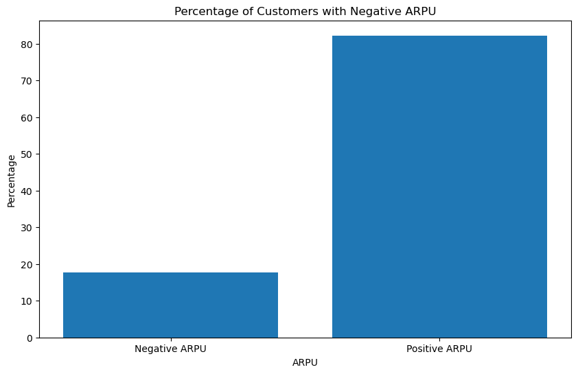

```python
# calculate the percentage of customers with negative ARPU
negative_arpu_percentage = (df[df['arpu'] < 0]['arpu'].count() / df.shape[0]) * 100

# create a bar plot to visualize the negative ARPU percentage
plt.figure(figsize=(10,6))
plt.bar(['Negative ARPU', 'Positive ARPU'], [negative_arpu_percentage, 100 - negative_arpu_percentage])
plt.title('Percentage of Customers with Negative ARPU')
plt.xlabel('ARPU')
plt.ylabel('Percentage')
plt.show()
```

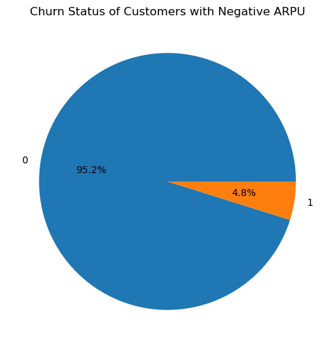

```python
# the relationship between negative ARPU and churn status
churn_negative_arpu = df[df['arpu'] < 0]['Churn Value'].value_counts(normalize=True)

# create a pie chart to visualize the churn status of customers with negative ARPU
plt.figure(figsize=(10,6))
plt.pie(churn_negative_arpu, labels=churn_negative_arpu.index, autopct='%1.1f%%')
plt.title('Churn Status of Customers with Negative ARPU')
plt.show()
```

**Observation**:

- 95.2% of customers with negative ARPU did not churn, while only 4.8% of customers with negative ARPU churned.
- This suggests that having negative ARPU is not necessarily a strong predictor of churn. However, further analysis is needed to fully understand the relationship between negative ARPU and churn. Other factors, such as usage patterns, service subscriptions, and customer satisfaction, may also play a role in predicting churn.
- It's possible that the negative ARPU is a result of money spent by the company to retain customers but negative ARPU could also be a result of other factors, such as accounts that have been inactive for a long time or delinquent accounts with outstanding balances.
- Additionally, the 4.8% of customers with negative ARPU who churned may have done so for reasons such as finding a better deal elsewhere.

```python
# Lets analyze further

negative_arpu_churn = df[(df['arpu'] < 0) & (df['Churn Value'] == 1)]

print("Number of customers with negative ARPU who churned: ", len(negative_arpu_churn['Customer ID']))
```

```
Number of customers with negative ARPU who churned:  5610
```

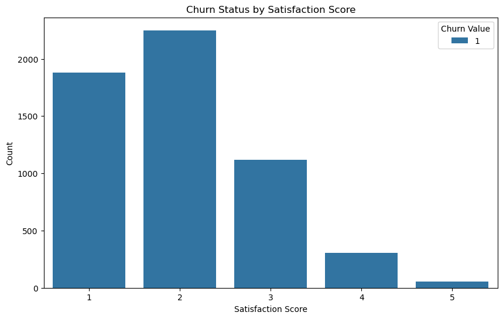

```python
# count plot of negative churned
plt.figure(figsize=(10,6))
sns.countplot(x='Satisfaction Score', hue='Churn Value', data=negative_arpu_churn)

# add labels and title
plt.xlabel('Satisfaction Score')
plt.ylabel('Count')
plt.title('Churn Status by Satisfaction Score')
plt.show()
```

```python
# calculate the average customer satisfaction score for this group
avg_satisfaction = negative_arpu_churn['Satisfaction Score'].mean()
print("Average customer satisfaction score:", round(avg_satisfaction,2))
```

```
Average customer satisfaction score: 2.0
```

**Observation**:

- The average customer satisfaction score for churned customers with negative ARPU is 2, it suggests that these customers were not satisfied with the services provided by the telecom company.
- It could mean that the company needs to improve its services and support to retain its customers.

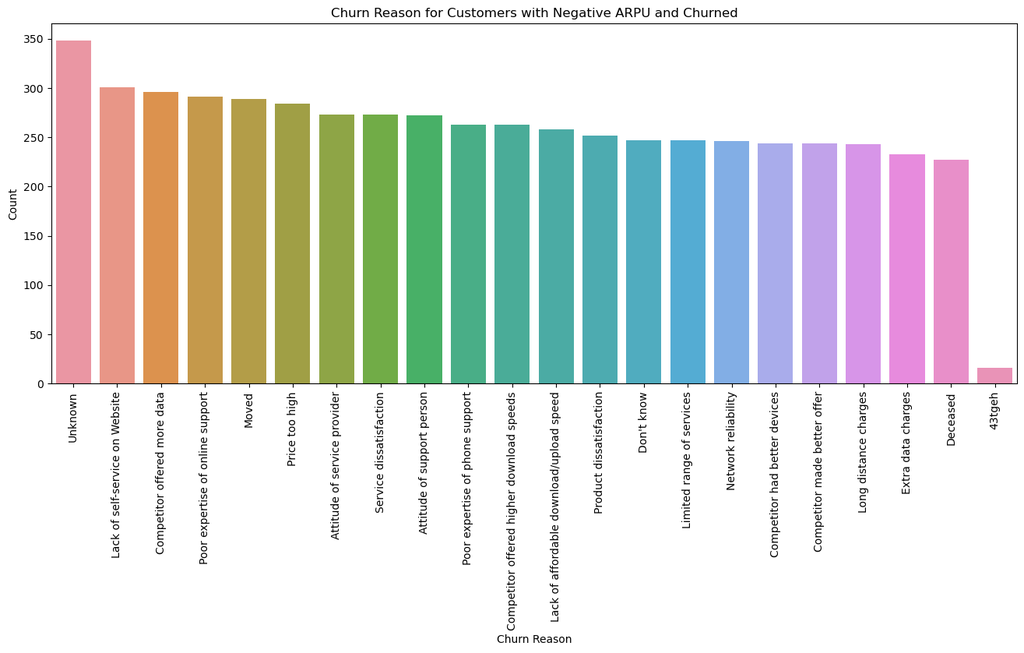

```python
# count the number of customers for each churn reason
churn_reason_counts = negative_arpu_churn['Churn Reason'].value_counts()

# plot the churn reason counts
plt.figure(figsize=(16,6))
sns.barplot(x=churn_reason_counts.index, y=churn_reason_counts)
plt.title('Churn Reason for Customers with Negative ARPU and Churned')
plt.xlabel('Churn Reason')
plt.ylabel('Count')
plt.xticks(rotation=90)
plt.show()
```

**Observation**:

- The distribution of churn reasons is quite similar, which makes it difficult to draw clear conclusions. However, there are a few observations we can make.
- The most common reason for churn is "Unknown," which could suggest that the company needs to do a better job of tracking and understanding customer behavior and reasons for leaving.
- Other common reasons for churn include price, service dissatisfaction, and network reliability, which could indicate that the company needs to focus on improving the quality of its service and offering competitive pricing to retain customers.
- The fact that many customers cited competitor offerings as a reason for leaving suggests that the company may need to do a better job of differentiating itself in the market.
- The presence of unusual reasons such as "43tgeh" with only 16 counts could indicate data entry errors or outliers that should be investigated and corrected.

### **ARPU and Customer Demographics**

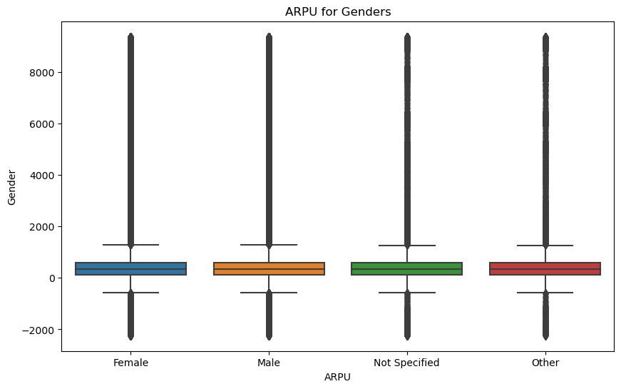

```python
# Plot arpu vs gender
plt.figure(figsize=(10,6))
sns.boxplot(x='Gender', y='arpu', data=df)
plt.title('ARPU for Genders')
plt.xlabel('ARPU')
plt.ylabel('Gender')
plt.show()
```

**Observation**:

- No relationship between Gender and ARPU.

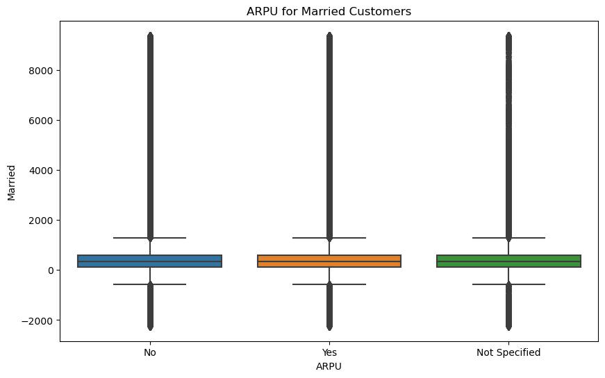

```python
# Plot arpu vs married
plt.figure(figsize=(10,6))
sns.boxplot(x='Married', y='arpu', data=df)
plt.title('ARPU for Married Customers')
plt.xlabel('ARPU')
plt.ylabel('Married')
plt.show()
```

### **ARPU and Churn Value**

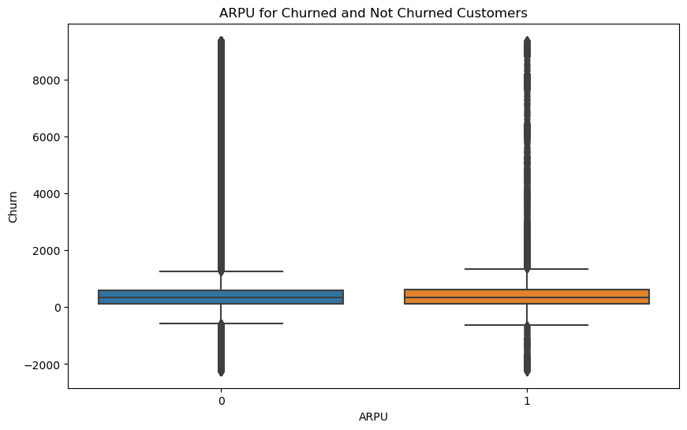

```python
# plot arpu vs churn

plt.figure(figsize=(10,6))
sns.boxplot(x='Churn Value', y='arpu', data=df)
plt.title('ARPU for Churned and Not Churned Customers')
plt.xlabel('ARPU')
plt.ylabel('Churn')
plt.show()
```

### **ARPU 4G**

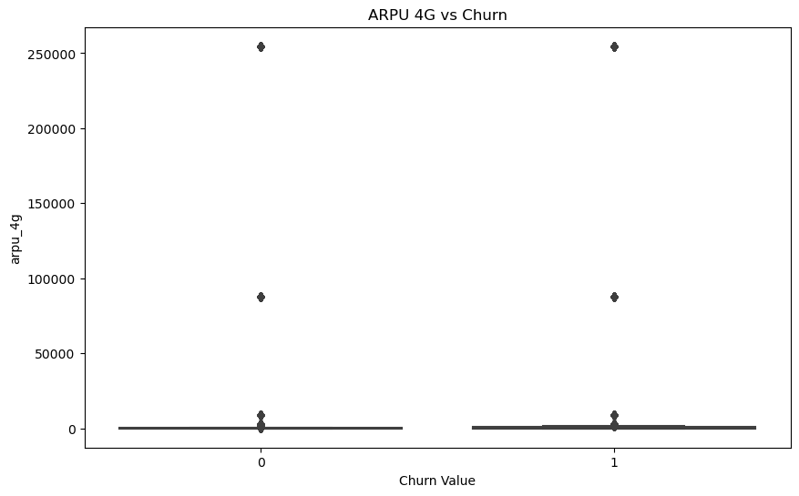

```python
# Box plot for ARPU 4G against churn
plt.figure(figsize=(10,6))
sns.boxplot(x='Churn Value', y='arpu_4g', data=df)
plt.title('ARPU 4G vs Churn')
plt.show()
```

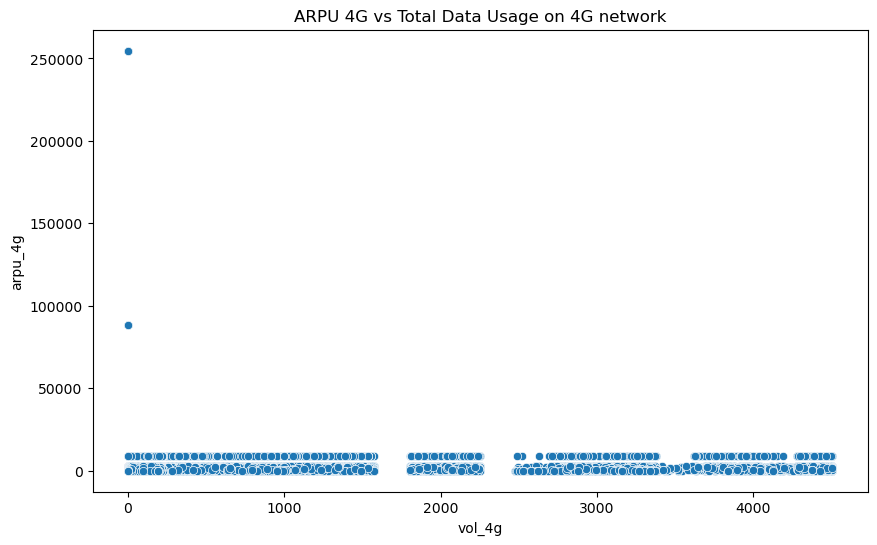

```python
# Scatter plot for ARPU 4G against total data usage
plt.figure(figsize=(10,6))
sns.scatterplot(x='vol_4g', y='arpu_4g', data=df)
plt.title('ARPU 4G vs Total Data Usage on 4G network')
plt.show()
```

**Observations**:

### **ARPU 5G**

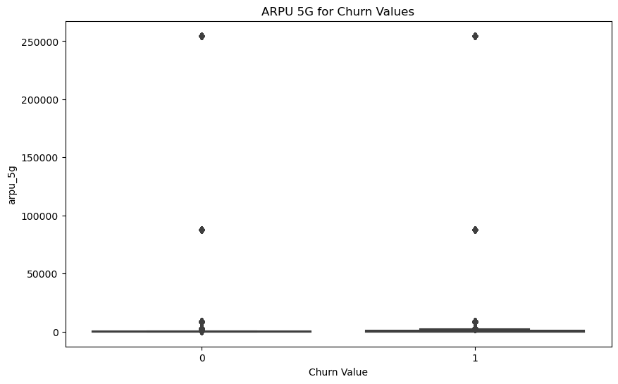

```python
# Box plot for ARPU 5G and Churn value
plt.figure(figsize=(10,6))
sns.boxplot(data=df, x='Churn Value', y='arpu_5g')
plt.title('ARPU 5G for Churn Values')
plt.show()
```

### **Night Pack User**

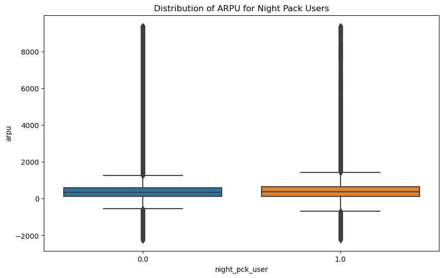

```python
# Box plot for Night pack user and ARPU
plt.figure(figsize=(10,6))
sns.boxplot(x='night_pck_user', y='arpu', data=df)
plt.title('Distribution of ARPU for Night Pack Users')
plt.show()
```

### **Chi Square Test for Association**

A sample's distribution of a categorical variable must frequently be compared to the distribution of a categorical variable in another sample.

The chi squared test of independence, often known as the chi squared test of association, is used to detect whether or not categorical variables are related.

The data must meet the following requirements for this test:

- Categorical variables
- Sample size is relatively large
- Independent observations

The chi squared test is performed in the following steps:

- Find a "expected" number (E) for each observed number (0) in the table.

$$χ^2 = \frac{∑(O_i – E_i)^2}{E_i}$$

- A chi-square test will provide us with a p-value. The p-value indicates whether or not our test results are significant.

However, in order to do a chi-square test and calculate the p-value, we need two pieces of information:

- Degrees of freedom. That is simply the number of categories minus one.
- Significance Level. The standard alpha level is 0.05 (5%), but alternative values such as 0.01 or 0.10 are possible.
- The following are the different values of p that indicate different hypothesis interpretations:
- P = 0.05; Hypothesis is rejected
- P > 0.05; Acceptance of Hypothesis

For categorical features, we'll use a Chi Squared ($\chi^2$) test to observe whether each categorical feature pair is correlated.

First, we calculate the $\chi^2$ values, p-values and degrees of freedom:

```python
# Categorical variables

cat_vars_for_test = [
 'Gender',
 'Married',
 'Dependents',
 'night_pck_user',
 'fb_user',
 'Referred a Friend',
 'Phone Service',
 'Multiple Lines',
 'Internet Service',
 'Internet Type',
 'Online Security',
 'Online Backup',
 'Device Protection Plan',
 'Premium Tech Support',
 'Streaming TV',
 'Streaming Movies',
 'Streaming Music',
 'Unlimited Data',
 'Churn Category',
 'offer']
```

```python
# Chi-square tests
from scipy.stats import chi2_contingency

for var in cat_vars_for_test:
    # Create binary encoded variables for categorical variable
    df_encoded = pd.get_dummies(df[var], prefix=var, drop_first=True)
    df_encoded['Churn Value'] = df['Churn Value']

    # Calculate chi-square test statistic and p-value
    chi2, p_val, dof, expected = chi2_contingency(pd.crosstab(df_encoded.iloc[:, 1], df_encoded['Churn Value']))

    if p_val < 0.05:
        print("---------------------------------")
        print(f'Statistically significant association between {var} and Churn')
        print('P-Value:', p_val)
    else:
        pass
```

```
---------------------------------
Statistically significant association between Married and Churn
P-Value: 0.040058331482657236
---------------------------------
Statistically significant association between night_pck_user and Churn
P-Value: 0.0
---------------------------------
Statistically significant association between fb_user and Churn
P-Value: 0.0
---------------------------------
Statistically significant association between Referred a Friend and Churn
P-Value: 0.0
---------------------------------
Statistically significant association between Phone Service and Churn
P-Value: 0.0
---------------------------------
Statistically significant association between Internet Service and Churn
P-Value: 0.0
---------------------------------
Statistically significant association between Online Security and Churn
P-Value: 0.0
---------------------------------
Statistically significant association between Online Backup and Churn
P-Value: 0.0
---------------------------------
Statistically significant association between Device Protection Plan and Churn
P-Value: 0.0
---------------------------------
Statistically significant association between Premium Tech Support and Churn
P-Value: 0.0
---------------------------------
Statistically significant association between Streaming TV and Churn
P-Value: 0.0
---------------------------------
Statistically significant association between Streaming Movies and Churn
P-Value: 0.0
---------------------------------
Statistically significant association between Streaming Music and Churn
P-Value: 0.0
---------------------------------
Statistically significant association between Churn Category and Churn
P-Value: 0.0
---------------------------------
Statistically significant association between offer and Churn
P-Value: 1.7025679102311887e-171
```

### **Single Way ANOVA**

ANOVA, or Analysis of Variance, is a statistical method used to test whether there are significant differences between the means of two or more groups. It is a generalization of t-tests, which can only be used to compare two groups, and is commonly used in experimental design and analysis.

In order to perform ANOVA, you need at least one continuous variable and one categorical variable that separates your data into comparison groups. The test compares the variance of group means to the variance of the groups, which allows you to determine if the groups are part of a larger population or if they are separate populations with different means.

The null hypothesis for ANOVA is that all groups have the same mean, while the alternative hypothesis is that at least one group has a different mean. The test calculates $F$ values, which are the ratio of the between- and within-group mean squares, and p-values. The $F$ value is used to determine whether or not the means of the groups are significantly different, while the p-value is used to determine the probability of obtaining a certain $F$ value by chance.

It is important to note that ANOVA only tells you that there is a difference between groups, but not where the difference is.

Overall, ANOVA is a powerful statistical tool that can help you understand whether there are significant differences between the means of different groups. It can be used in a wide range of fields, including biology, psychology, and engineering, to help researchers gain insights into their data and make informed decisions.

```python
from scipy.stats import f_oneway

# Loop over each numeric variable and test its association with churn using ANOVA
for var in num_vars:
    churn_yes = df[df['Churn Value'] == 1][var]
    churn_no = df[df['Churn Value'] == 0][var]
    f_statistic, p_value = f_oneway(churn_yes, churn_no)


    if p_value < 0.05:
        print('Statistically Significant')
        print('Variable:', var)
        print('Churn Yes Mean:', churn_yes.mean())
        print('Churn No Mean:', churn_no.mean())
        print('F-Statistic:', f_statistic)
        print('P-Value:', p_value)
        print('------------------')
    else:
        pass
```

```
Statistically Significant
Variable: arpu
Churn Yes Mean: 893.4254240750026
Churn No Mean: 775.8239644295007
F-Statistic: 120.70203292065581
P-Value: 4.465829505159502e-28
------------------
Statistically Significant
Variable: roam_ic
Churn Yes Mean: 350.1657366491199
Churn No Mean: 244.83795606401316
F-Statistic: 1758.3817177879482
P-Value: 0.0
------------------
Statistically Significant
Variable: roam_og
Churn Yes Mean: 289.38338243125617
Churn No Mean: 266.51000635138445
F-Statistic: 38.10070628345149
P-Value: 6.722505058328547e-10
------------------
Statistically Significant
Variable: loc_og_t2t
Churn Yes Mean: 1377.5590386136696
Churn No Mean: 808.6377267975191
F-Statistic: 3671.289109123182
P-Value: 0.0
------------------
Statistically Significant
Variable: loc_og_t2m
Churn Yes Mean: 904.6051610523011
Churn No Mean: 667.7334588020211
F-Statistic: 1294.6366767894601
P-Value: 3.141752570608995e-283
------------------
Statistically Significant
Variable: loc_og_t2f
Churn Yes Mean: 65.22954191646217
Churn No Mean: 30.691609659149236
F-Statistic: 9908.917280196865
```

[output cut: 141 more lines]

```
------------------
Statistically Significant
Variable: aug_vbc_5g
Churn Yes Mean: 634.7006817093318
Churn No Mean: 525.5438034279163
F-Statistic: 172.60918714216697
P-Value: 2.0152231895684624e-39
------------------
Statistically Significant
Variable: Satisfaction Score
Churn Yes Mean: 1.9873430436966348
Churn No Mean: 3.1864918062216296
F-Statistic: 27367.398959997576
P-Value: 0.0
------------------
```

### **Churn Value**

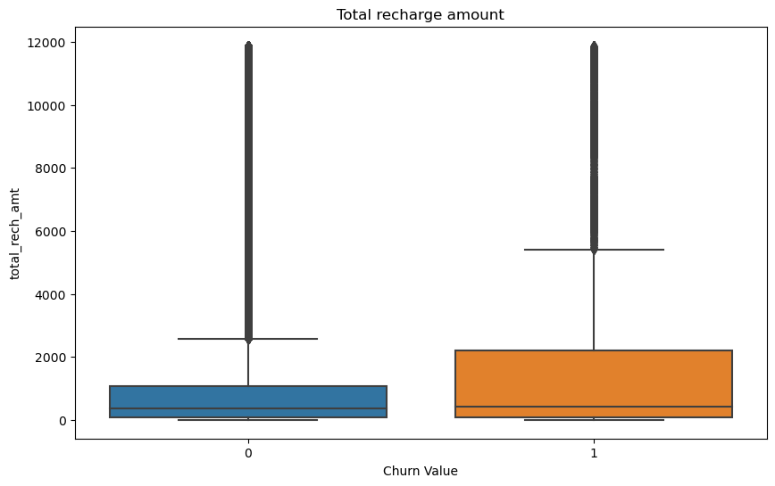

```python
# Box plot for Churn value and total recharge amount
plt.figure(figsize=(10,6))
sns.boxplot(x='Churn Value', y='total_rech_amt', data=df)
plt.title('Total recharge amount')
plt.show()
```

**Observation:**

It appears that customers who churned had a higher total recharge amount compared to customers who did not churn. This observation suggests that the amount of money that a customer spends on recharges may be a significant factor in their decision to churn.

This observation can provide valuable insights for the business. If customers who churned had a higher total recharge amount, it could mean that they were dissatisfied with the quality or value of the services provided by the company, even though they were spending more money. Therefore, the business may need to investigate and address the reasons behind the dissatisfaction to retain high-value customers.

In addition, the observation that customers who churned had a higher total recharge amount suggests that identifying and targeting high-value customers for retention efforts may be an effective strategy. By focusing on retaining customers who spend more money, the business can potentially improve their overall revenue and profitability.

### **Referred a friend and Churn**

**Hypothesis**:

- Customers who refer friends are less likely to churn.

```
             Number of Referrals
Churn Value
0                       4.336284
1                       4.373074
```

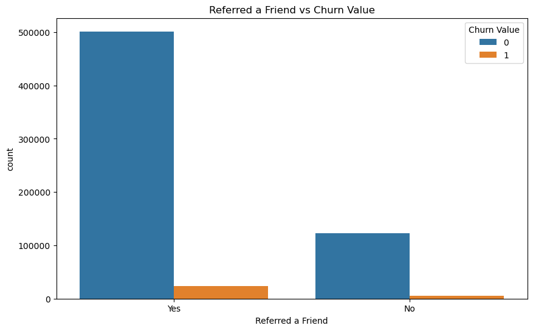

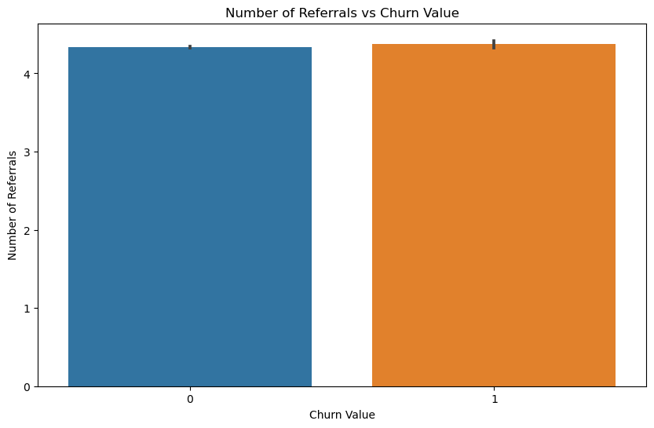

```python
# pivot table
pivot_table = pd.pivot_table(df, values=['Referred a Friend', 'Number of Referrals'], index=['Churn Value'], aggfunc=np.mean)

# Print the pivot table
print(pivot_table)

# Plot the pivot table
plt.figure(figsize=(10,6))
sns.countplot( x='Referred a Friend', data=df, hue='Churn Value')
plt.title('Referred a Friend vs Churn Value')
plt.show()


plt.figure(figsize=(10,6))
sns.barplot(x='Churn Value', y='Number of Referrals', data=df)
plt.title('Number of Referrals vs Churn Value')
plt.show()
```

Let's calculate churn rate in both groups!

```python
refer_group = df.groupby("Referred a Friend")

refer_group_churn_rates = refer_group["Churn Value"].mean() * 100

refer_group_churn_rates
```

```
Referred a Friend
No     4.514279
Yes    4.581415
Name: Churn Value, dtype: float64
```

**Observation:**

If customers who have referred others to the company are churning more, it could suggest that the company's referral program is not effective at retaining customers. This may be due to a variety of reasons, such as:

The referral program may not be providing sufficient incentives or rewards to encourage customers to stay. Customers who refer others may have higher expectations of the company and its services, and may be more likely to churn if those expectations are not met.

```python
# To make the analysis more thorough, we can combine the Phone Service column with other related columns such as Multiple Lines, Internet Service, and Internet Type. This would give us a better understanding of the customer's overall service usage.

# Cross-tabulate Phone Service with Multiple Lines
pd.crosstab(df['Phone Service'], df['Multiple Lines'], dropna=False)
```

| Multiple Lines Phone Service | No | None | Yes |
| --- | --- | --- | --- |
| No | 61330 | 8735 | 54505 |
| Yes | 261494 | 37345 | 230344 |

### **Try it out - I**

By analyzing the phone service column, you can identify how many customers have opted for phone services and how it impacts churn rate and other variables. For example, you may find that a large proportion of customers who churned did not have phone services. This could indicate that offering phone services could be an effective way to improve customer retention.

On the other hand, you may find that customers with phone services are more likely to churn. This may indicate that there are issues with the phone services that need to be addressed.

To gain a more detailed understanding of the impact of phone services on customer behavior and churn rate, you can combine the phone service column with other variables such as demographics, usage patterns, and service types. This can help you identify specific customer segments that are more likely to benefit from phone services or may be more sensitive to phone service issues. For example, you may find that older customers are more likely to value phone services, or that customers who use a lot of data may be less likely to need phone services.

Overall, analyzing the phone service column can provide valuable insights into how offering phone services impacts customer behavior and can inform strategies to improve customer retention and satisfaction.

### **Internet Service and Type**

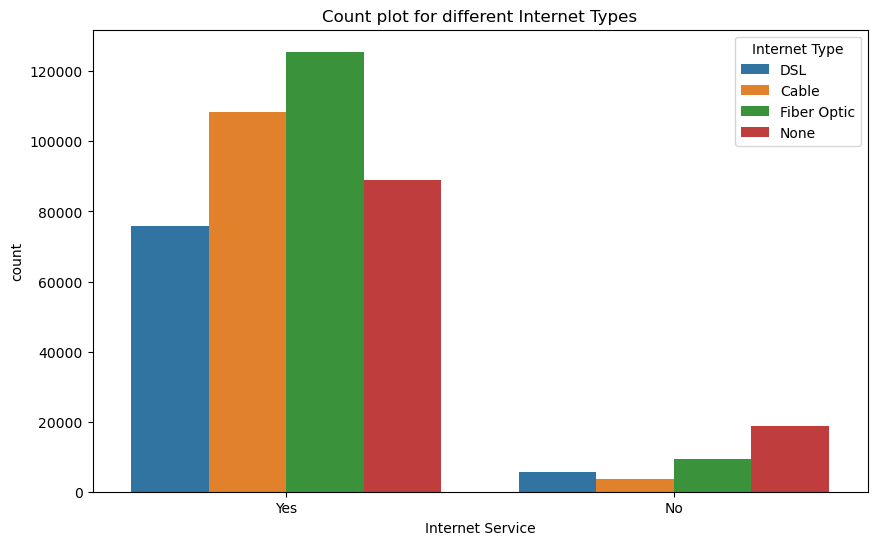

```python
# Count plot between internet service and type
plt.figure(figsize=(10,6))
sns.countplot(x='Internet Service', hue='Internet Type', data=df)
plt.title("Count plot for different Internet Types")
plt.show()
```

```python
# Internet service and type churn rate
df.groupby(['Internet Service', 'Internet Type'])['Churn Value'].mean()
```

```
Internet Service  Internet Type
No                Cable            0.042918
                  DSL              0.041006
                  Fiber Optic      0.047123
                  None             0.045377
Yes               Cable            0.045704
                  DSL              0.045763
                  Fiber Optic      0.045760
                  None             0.045332
Name: Churn Value, dtype: float64
```

**Observation:**

If the churn rates for all types of internet services are similar, it may indicate that the type of internet service does not have a significant impact on churn. However, it is also possible that there are other factors at play, such as pricing or customer service, that are more important drivers of churn. Further analysis, such as comparing the churn rates for different pricing tiers or customer service ratings, may be necessary to better understand the relationship between internet service and churn.

### **Unlimited Data**

```python
# distribution of data users for revenue
df.groupby('Unlimited Data')[['total_rech_amt','total_rech_data','arpu','Churn Value']].mean()
```

[output not shown]

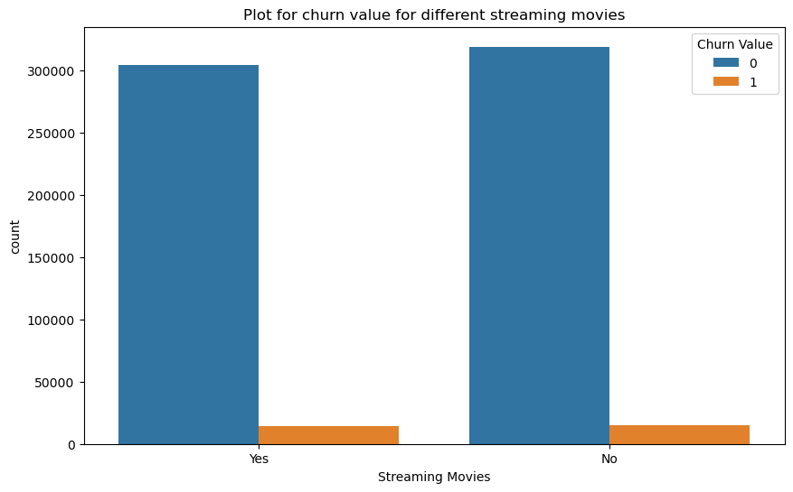

```python
# Plot a bar graph of the Streaming Movies column
plt.figure(figsize=(10,6))
sns.countplot(x='Streaming Movies', data=df, hue="Churn Value")
plt.title("Plot for churn value for different streaming movies")
plt.show()
```

The company may want to investigate why such a large percentage of customers do not use streaming movies and address any concerns or issues that may be preventing them from using the service , understand why and recommend measures.

Hypothesis: Customers with higher ARPU 5G are more likely to be satisfied with their service and less likely to churn.

### **Try it out - II**

Try to experiment with these hypotheses and generate insights.

**Hypotheses**:

- Customers who have subscribed for premium services such as fiber optic internet, streaming movies, and device protection plan are more likely to have a higher satisfaction score.
- Customers who have a longer tenure with the company are more likely to have a higher satisfaction score.

## **Multivariate Analysis**

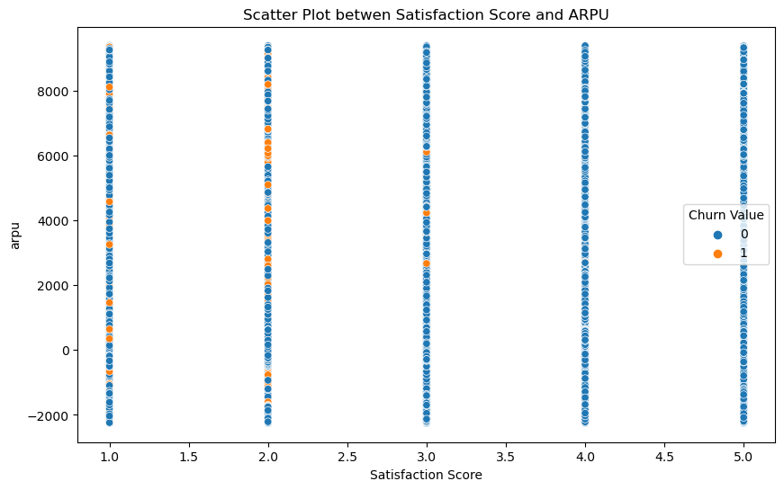

```python
# Relationship between arpu, satisfaction score and churn value
# the three major pillars of service quality
plt.figure(figsize=(10,6))
sns.scatterplot(data=df, x='Satisfaction Score',y='arpu', hue='Churn Value')
plt.title("Scatter Plot betwen Satisfaction Score and ARPU")
plt.show()
```

**Observation:**

#### **Correlation**

Correlation coefficient is used to measure the strength of relationship between two variables. It indicates that as the value of one variable changes the other variable changes in a specific direction with some magnitude. There are various ways to find correlation between two variables, one of which is Pearson correlation coefficient. It measures the linear relationship between two continuous variables.

Let's say $x$ and $y$ are two continuous variables, the Pearson correlation coefficient between them can be found by the following formula.

$$r = \frac{ \sum_{i=1}^{n}(x_i-\bar{x})(y_i-\bar{y}) }{% \sqrt{\sum_{i=1}^{n}(x_i-\bar{x})^2}\sqrt{\sum_{i=1}^{n}(y_i-\bar{y})^2}}$$

where $x_i$ and $y_i$ represents the $i^{th}$ value of the variables. The value of $r$ ranges between $-1$ and $+1$.

Their strength of relationship is measured by the absolute value of coefficient, whereas the sign of the coefficient indicates the direction of the relationship.

#### **Graphs of Different Correlation Coefficients**

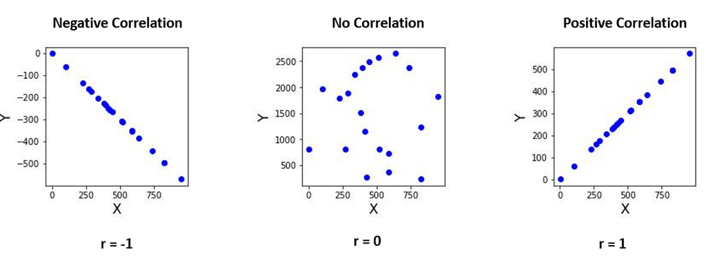

1. $r = -1$ indicates a perfect negative relationship between the variables
2. $r = 0$ indicates no relationship between the variables
3. $r = 1$ indicates a perfect positive relationship between the variables

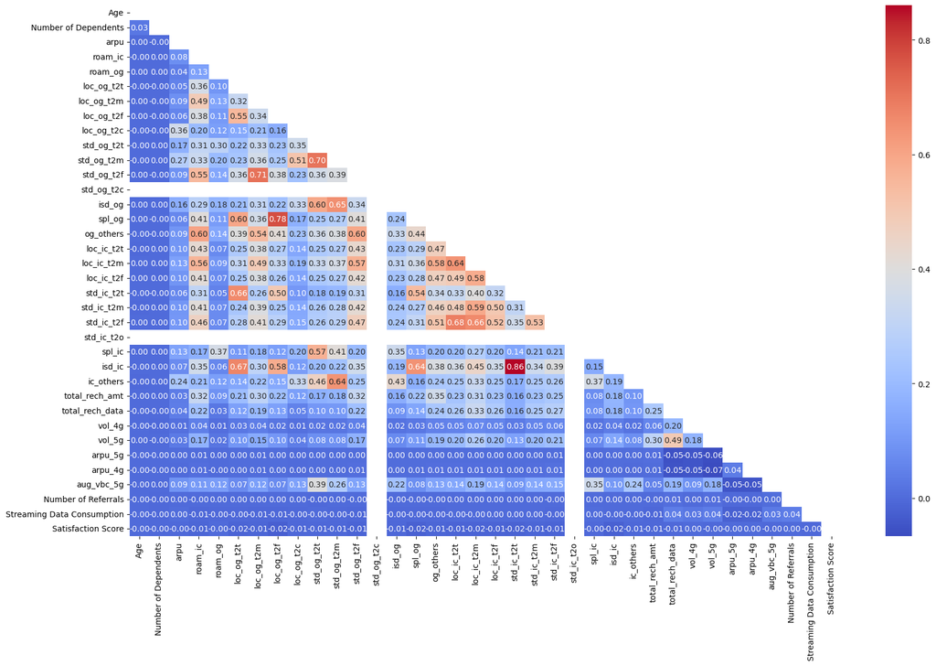

```python
# Creating correlation dataframe and generating heatmap
df_corr = df[num_vars].corr()
mask = np.zeros_like(df_corr)
mask[np.triu_indices_from(mask)] = True

plt.figure(figsize=(20,12))
sns.heatmap(df_corr, cmap='coolwarm', annot=True, fmt='.2f', mask=mask)
```

```python
# Printing highly correlated variables
corr_pairs = []
for i in range(len(df_corr.columns)):
    for j in range(i):
        if abs(df_corr.iloc[i, j]) >= 0.5:
            corr_pairs.append((df_corr.columns[i], df_corr.columns[j]))


if corr_pairs:
    print("Highly correlated variable pairs:")
    for pair in corr_pairs:
        print(pair[0], "and", pair[1])
else:
    print("No highly correlated variable pairs found.")
```

```
Highly correlated variable pairs:
loc_og_t2f and loc_og_t2t
std_og_t2m and loc_og_t2c
std_og_t2m and std_og_t2t
std_og_t2f and roam_ic
std_og_t2f and loc_og_t2m
isd_og and std_og_t2t
isd_og and std_og_t2m
spl_og and loc_og_t2t
spl_og and loc_og_t2f
og_others and roam_ic
og_others and loc_og_t2m
og_others and std_og_t2f
loc_ic_t2m and roam_ic
loc_ic_t2m and std_og_t2f
loc_ic_t2m and og_others
loc_ic_t2m and loc_ic_t2t
loc_ic_t2f and loc_ic_t2m
std_ic_t2t and loc_og_t2t
std_ic_t2t and spl_og
std_ic_t2m and loc_ic_t2m
std_ic_t2m and loc_ic_t2f
std_ic_t2f and og_others
std_ic_t2f and loc_ic_t2t
std_ic_t2f and loc_ic_t2m
std_ic_t2f and loc_ic_t2f
std_ic_t2f and std_ic_t2m
spl_ic and std_og_t2t
isd_ic and loc_og_t2t
isd_ic and loc_og_t2f
isd_ic and spl_og
isd_ic and std_ic_t2t
ic_others and std_og_t2m
```

### **Chatterjee Correlation**

Chatterjee correlation is a coefficient of correlation proposed by Sourav Chatterjee that measures the degree of dependence between two random variables without assuming anything about their distributions. It is a simple and interpretable measure of dependence that ranges between 0 and 1, where 0 indicates independence and 1 indicates that one variable is a measurable function of the other.

Compared to other correlation coefficients, the Chatterjee Correlation is less sensitive to outliers and non-linear relationships between variables. However, it requires more computational resources due to its non-parametric nature.

One advantage of the Chatterjee correlation is that it has a simple asymptotic theory under the hypothesis of independence, similar to classical coefficients like Pearson's and Spearman's correlations. This means that we can use it to test the null hypothesis of independence between two variables.

The calculation involves the following steps:

- Rank the values of Y in the data set, assigning the smallest value the rank of 1, the second smallest the rank of 2, and so on. Store these ranks in a new column called 'rank'.
- Rank the values of X in the data set, assigning the smallest value the rank of 1, the second smallest the rank of 2, and so on. Store these ranks in a new column called 'rank_x'.
- Sort the data set in increasing order of 'rank_x'.
- Calculate the absolute difference between the ranks of Y for consecutive values of X. Sum up these differences.
- Calculate the Chatterjee correlation coefficient using the formula: Chatterjee correlation coefficient = 1 - 3 * (sum of absolute differences in ranks) / (N^2 - 1), where N is the number of observations in the data set.
- The resulting Chatterjee correlation coefficient is a number between 0 and 1, with 0 indicating no dependence between the two variables and 1 indicating complete dependence.

Here's a [link](https://arxiv.org/pdf/1909.10140.pdf) to the the paper.

```python
#function for finding chatterejee correlation coefficient
def chatterjee_corr(df,x,y):
  N=df.shape[0]
  df_rank=df

  df_rank['rank']=df_rank[y].rank()
  # print(df_rank['rank'])

  df_rank['rank_x']=df_rank[x].rank()

  df_rank=df_rank.sort_values(by='rank_x')

  # 1-3*(abs(sum(xri-1 - Xir))/n square-1

  # Diff function --> summation -> absolute
  chatt_corr=1- (3*df_rank['rank'].diff().abs().sum() )/ (pow(N,2)-1)

  return chatt_corr
```

```python
# Taking few important variables generated from the insights earlier
num_vars_test = ['Age','Number of Dependents','arpu','roam_ic',
                    'roam_og', 'total_rech_amt', 'total_rech_data', 'vol_4g', 'vol_5g', 'arpu_5g','arpu_4g',
                    'aug_vbc_5g','Number of Referrals','Streaming Data Consumption','Satisfaction Score']
```

```python
# Looping over all numerical variables to check chatterjee correlation
for i, var in enumerate(num_vars_test):
    for j in range(i + 1, len(num_vars_test)):
        corr = chatterjee_corr(df,var, num_vars_test[j])
        if corr > 0.6:
            print(var, 'and', num_vars_test[j], ':', corr)
```

```
Age and Number of Dependents : 0.6760856044071273
total_rech_data and arpu_5g : 0.6644614940888286
total_rech_data and arpu_4g : 0.6680885946973494
vol_4g and vol_5g : 0.6343169121632295
arpu_5g and arpu_4g : 0.7502363507931655
```

**Observation**:

- Age and number of dependents have a moderate positive correlation (0.68). This suggests that as age increases, the number of dependents tends to increase as well.
- Total recharge data and arpu_5g have a moderate positive correlation (0.66). This suggests that customers who spend more on data tend to have higher revenue per user for 5G services.
- Total recharge data and arpu_4g have a moderate positive correlation (0.67). This suggests that customers who spend more on data tend to have higher revenue per user for 4G services.
- Vol_4g and vol_5g have a moderate positive correlation (0.63). This suggests that customers who use more 4G data tend to use more 5G data as well.
- Arpu_5g and arpu_4g have a strong positive correlation (0.75). This suggests that customers who spend more on 5G services tend to spend more on 4G services as well.

### **Try it out - III: Experiment with Data Processing and Feature Engineering Techniques**

- Start by selecting one or more variables from the dataset that have not been explored yet in the previous analyses. This could include variables related to customer behavior, usage patterns, or demographics.
- Explore the distribution of these variables using histograms, countplots, and boxplots.
- Identify any outliers or unusual patterns in the data that might need to be addressed before further analysis.
- Experiment with different data processing techniques such as scaling, normalization, or log transformation to see how they affect the distribution and relationships between variables.
- Consider feature engineering techniques such as creating new variables by combining existing ones, or encoding categorical variables using techniques such as one-hot encoding or label encoding.
- Use correlation analysis to investigate the relationships between the new variables and the target variable of customer churn.
- Compare the results of the new analysis with the previous analysis to see if the new variables or processing techniques provide any new insights into customer churn and satisfaction score.
- Draw conclusions and provide recommendations based on the new analysis and insights gained.
- Repeat the process with other variables in the dataset to explore different aspects of customer behavior and usage patterns.

## **Project Summary**

In this project, we analyzed a telecom dataset with the aim of identifying insights and making recommendations for the business. We performed univariate, bivariate, and multivariate analyses to identify patterns and relationships between various variables.

Through EDA, we identified that the company lacks targeted marketing for specific customers, satisfaction scores are low, and the major reasons for churn were attitude of customer support and competition offering better deals.

Our future scope includes implementing machine learning algorithms for predictive analysis, conducting A/B testing, and continuously monitoring and improving customer satisfaction.